# Part I - Ford GoBike System Data

## Introduction

Ford GoBike is a bike sharing system located and covering the San FranciscoBay area. It provides more than 4,000 bikes distributed across different accessible locations allowing customers to get bikes from one station and return to any other station in the system, making them ideal, accessible, and convenient for one-way trips, for special and urgent occasions. The bikes are available for use 24 hours/day, all days of the week, and all days of the year. Customers have the possibility to become subscribers through a monthly or yearly subscriptions or simply purchase one ride for a determined number of hours.

## Preliminary Wrangling

```python
# import all packages and set plots to be embedded inline
import numpy as np
import pandas as pd
import matplotlib.pyplot as plt
import seaborn as sb

%matplotlib inline
```

```python
df = pd.read_csv('201902-fordgobike-tripdata.csv')
```

```python
df.head()
```

|  | duration_sec | start_time | end_time | start_station_id | start_station_name | start_station_latitude | start_station_longitude | end_station_id | end_station_name | end_station_latitude | end_station_longitude | bike_id | user_type | member_birth_year | member_gender | bike_share_for_all_trip |
| --- | --- | --- | --- | --- | --- | --- | --- | --- | --- | --- | --- | --- | --- | --- | --- | --- |
| 0 | 52185 | 2019-02-28 17:32:10.1450 | 2019-03-01 08:01:55.9750 | 21.0 | Montgomery St BART Station (Market St at 2nd St) | 37.789625 | -122.400811 | 13.0 | Commercial St at Montgomery St | 37.794231 | -122.402923 | 4902 | Customer | 1984.0 | Male | No |
| 1 | 42521 | 2019-02-28 18:53:21.7890 | 2019-03-01 06:42:03.0560 | 23.0 | The Embarcadero at Steuart St | 37.791464 | -122.391034 | 81.0 | Berry St at 4th St | 37.775880 | -122.393170 | 2535 | Customer | NaN | NaN | No |
| 2 | 61854 | 2019-02-28 12:13:13.2180 | 2019-03-01 05:24:08.1460 | 86.0 | Market St at Dolores St | 37.769305 | -122.426826 | 3.0 | Powell St BART Station (Market St at 4th St) | 37.786375 | -122.404904 | 5905 | Customer | 1972.0 | Male | No |
| 3 | 36490 | 2019-02-28 17:54:26.0100 | 2019-03-01 04:02:36.8420 | 375.0 | Grove St at Masonic Ave | 37.774836 | -122.446546 | 70.0 | Central Ave at Fell St | 37.773311 | -122.444293 | 6638 | Subscriber | 1989.0 | Other | No |
| 4 | 1585 | 2019-02-28 23:54:18.5490 | 2019-03-01 00:20:44.0740 | 7.0 | Frank H Ogawa Plaza | 37.804562 | -122.271738 | 222.0 | 10th Ave at E 15th St | 37.792714 | -122.248780 | 4898 | Subscriber | 1974.0 | Male | Yes |

```python
df.shape
```

```
(183412, 16)
```

```python
df.duplicated().sum()
```

```
0
```

```python
df.info()
```

```
<class 'pandas.core.frame.DataFrame'>
RangeIndex: 183412 entries, 0 to 183411
Data columns (total 16 columns):
 #   Column                   Non-Null Count   Dtype
---  ------                   --------------   -----
 0   duration_sec             183412 non-null  int64
 1   start_time               183412 non-null  object
 2   end_time                 183412 non-null  object
 3   start_station_id         183215 non-null  float64
 4   start_station_name       183215 non-null  object
 5   start_station_latitude   183412 non-null  float64
 6   start_station_longitude  183412 non-null  float64
 7   end_station_id           183215 non-null  float64
 8   end_station_name         183215 non-null  object
 9   end_station_latitude     183412 non-null  float64
 10  end_station_longitude    183412 non-null  float64
 11  bike_id                  183412 non-null  int64
 12  user_type                183412 non-null  object
 13  member_birth_year        175147 non-null  float64
 14  member_gender            175147 non-null  object
 15  bike_share_for_all_trip  183412 non-null  object
dtypes: float64(7), int64(2), object(7)
memory usage: 22.4+ MB
```

Based on the information provided on the dataframe, data cleaning is required before moving to the data exploration.

#### Quality Data Issues

1. Change data type of 'start_time', 'end_time', 'member_birth_year' to datetime and id columns from float to integers
2. Remove missing data

#### Tidiness Issues

1. Drop Unecessary columns like Lattitude and Longitude columns.

## Data Cleaning

### Issue 1: Wrong Datatypes

**Define:** Change all the wrong datatypes as described in the above

**Code:**

```python
# df["start_time"] = pd.to_datetime(df["start_time"])
# df["end_time"] = pd.to_datetime(df["end_time"])
# # df["member_birth_year"] = pd.to_datetime(df["member_birth_year"])
df["start_station_id"]= df["start_station_id"].astype(str)
df["end_station_id"]= df["end_station_id"].astype(str)
```

#### Note

**Test:**

```python
df.info()
```

```
<class 'pandas.core.frame.DataFrame'>
RangeIndex: 183412 entries, 0 to 183411
Data columns (total 16 columns):
 #   Column                   Non-Null Count   Dtype
---  ------                   --------------   -----
 0   duration_sec             183412 non-null  int64
 1   start_time               183412 non-null  object
 2   end_time                 183412 non-null  object
 3   start_station_id         183412 non-null  object
 4   start_station_name       183215 non-null  object
 5   start_station_latitude   183412 non-null  float64
 6   start_station_longitude  183412 non-null  float64
 7   end_station_id           183412 non-null  object
 8   end_station_name         183215 non-null  object
 9   end_station_latitude     183412 non-null  float64
 10  end_station_longitude    183412 non-null  float64
 11  bike_id                  183412 non-null  int64
 12  user_type                183412 non-null  object
 13  member_birth_year        175147 non-null  float64
 14  member_gender            175147 non-null  object
 15  bike_share_for_all_trip  183412 non-null  object
dtypes: float64(5), int64(2), object(9)
memory usage: 22.4+ MB
```

### Issue 2: Missing Values

**Define:** Remove all the missing values

**Code:**

```python
na_counts = df.isna().sum()
print(na_counts)
```

```
duration_sec                  0
start_time                    0
end_time                      0
start_station_id              0
start_station_name          197
start_station_latitude        0
start_station_longitude       0
end_station_id                0
end_station_name            197
end_station_latitude          0
end_station_longitude         0
bike_id                       0
user_type                     0
member_birth_year          8265
member_gender              8265
bike_share_for_all_trip       0
dtype: int64
```

### Charts' Colors

```python
color = sb.color_palette('pastel')
color
```

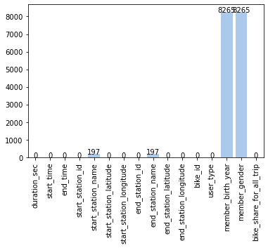

```python
sb.barplot(na_counts.index.values, na_counts, color = color[0])
plt.xticks(rotation=90);
for i in range (na_counts.shape[0]):
    count = na_counts[i]
    plt.text(i, count+300, count, ha = 'center', va='top');
```

#### Conclusion about missing values

After checking in details the missing values, we will be removing only the small amount of missing values. In other words, we will only drop missing values in the station names and id columns an will keep the other two columns as they have a large number of missing data, in a first place. In later analysis when the rows with missing data will be required, the missing values will be dropped.

```python
df = df.dropna(subset=['start_station_name'])
```

```python
df.isnull().sum()
```

```
duration_sec                  0
start_time                    0
end_time                      0
start_station_id              0
start_station_name            0
start_station_latitude        0
start_station_longitude       0
end_station_id                0
end_station_name              0
end_station_latitude          0
end_station_longitude         0
bike_id                       0
user_type                     0
member_birth_year          8263
member_gender              8263
bike_share_for_all_trip       0
dtype: int64
```

### Issue 3: Drop unecessary columns

**Define:** Some columns will not required for this analysis, for that, they will be dropped

**Code:**

```python
df.drop(['start_station_latitude', 'start_station_longitude', 'end_station_latitude', 'end_station_longitude'], axis=1, inplace=True)
```

**Test:**

```python
df.info()
```

```
<class 'pandas.core.frame.DataFrame'>
Int64Index: 183215 entries, 0 to 183411
Data columns (total 12 columns):
 #   Column                   Non-Null Count   Dtype
---  ------                   --------------   -----
 0   duration_sec             183215 non-null  int64
 1   start_time               183215 non-null  object
 2   end_time                 183215 non-null  object
 3   start_station_id         183215 non-null  object
 4   start_station_name       183215 non-null  object
 5   end_station_id           183215 non-null  object
 6   end_station_name         183215 non-null  object
 7   bike_id                  183215 non-null  int64
 8   user_type                183215 non-null  object
 9   member_birth_year        174952 non-null  float64
 10  member_gender            174952 non-null  object
 11  bike_share_for_all_trip  183215 non-null  object
dtypes: float64(1), int64(2), object(9)
memory usage: 18.2+ MB
```

### What is the structure of your dataset?

The Ford GoBike System Data is a dataframe was compoed of 16 columns and 183412 rows, before the cleaning process. It was necssary to clean the data before moving the explanatory analysis and now it is composed of 12 columns and 183215. The dataframe has different data types like objects, integers (64), and float64.

### What is/are the main feature(s) of interest in your dataset?

This dataset is really rich to analyse and interpret. The main features that would be interesting to explore are:

1. Most timing when the trips were taken considering the time of day, day of the week, and month of the year.
2. Duration of a trip (bike ride)
3. Characteristics of the members in terms of **age**, **gender**, and **user type**. With that being said, the company can work on the core segment to convert more customers into subscribers and to attract new members.
4. The relationship between the user type and the timing and duration of bike rides (whether the user type affect these variables)
5. Most used bikes for the trips. We can conclude whether there is a special type of bike for rides or prefered by members.
6. Start and End Stations. This can provide helpful insights to make improvement in the less considered stations and implement marketing strategies to attract more members and gain more subscribers.

### What features in the dataset do you think will help support your investigation into your feature(s) of interest?

To find interesting insights and answer these questions, all the variables will be required. The following variables will be the main ones: the trip duration, the start and end station, the bike id, the users' types, the members' ages and genders, the date (time, day, month, and year). All the features will be used in the open investigation through studying each variable separately or in relationships with other variables.

## Univariate Exploration

### Most Commun Start and End Locations

#### Question: What are the most common start and end stations?

#### Visualization

```python
df.start_station_name.nunique()
```

```
329
```

```python
#Start Location
start_station_counts = df['start_station_name'].value_counts().head(10)
start_station_counts
#End location
end_station_counts = df['end_station_name'].value_counts().head(10)
end_station_counts
```

```
San Francisco Caltrain Station 2  (Townsend St at 4th St)    4857
Market St at 10th St                                         3973
Montgomery St BART Station (Market St at 2nd St)             3647
San Francisco Ferry Building (Harry Bridges Plaza)           3368
Powell St BART Station (Market St at 4th St)                 2997
San Francisco Caltrain (Townsend St at 4th St)               2947
Berry St at 4th St                                           2872
The Embarcadero at Sansome St                                2512
Powell St BART Station (Market St at 5th St)                 2353
Steuart St at Market St                                      2338
Name: end_station_name, dtype: int64
```

```python
# Obtenir les valeurs uniques de la colonne « type » par ordre de fréquence décroissante.
#for the start location
start_station_order = start_station_counts.index
start_station_order
#for the end Location
end_station_order = end_station_counts.index
end_station_order
```

```
Index(['San Francisco Caltrain Station 2  (Townsend St at 4th St)',
       'Market St at 10th St',
       'Montgomery St BART Station (Market St at 2nd St)',
       'San Francisco Ferry Building (Harry Bridges Plaza)',
       'Powell St BART Station (Market St at 4th St)',
       'San Francisco Caltrain (Townsend St at 4th St)', 'Berry St at 4th St',
       'The Embarcadero at Sansome St',
       'Powell St BART Station (Market St at 5th St)',
       'Steuart St at Market St'],
      dtype='object')
```

```python
def create_plot(data, x, order, title, xlabel, ylabel, isSubplot, sp1=1, sp2=2, sp3=1, y=None, withRotation=False, plotType='countPlot', height=None,) :
    #Histogramme on the left about the name of the start location
    if isSubplot :
        plt.subplot(sp1,sp2,sp3)
    sb.countplot(data=data, x=x, color=color[0], order=order, y=y)
    if withRotation :
        plt.xticks(rotation = 90);
    plt.title(title)
    plt.xlabel(xlabel)
    plt.ylabel(ylabel)

def create_pie_plot(data, order, title, labels, colors) :
    plt.pie(order, labels =labels, colors = colors , startangle = 90, counterclock = False, autopct='%.0f%%', radius = 10);
    plt.title(title, size = 15)
    plt.axis('square');

def create_bar_plot(x, height, colors, xlabel, ylabel, title) :
    plt.bar(x=x, height=height, color=colors);
    plt.xlabel(xlabel)
    plt.ylabel(ylabel)
    plt.title(title)
    plt.show();

def create_histogramme (data, x, bins, color, title, xlabel, ylabel):
    plt.hist(data = data, x = x, bins = bins, color = color)
    plt.xlabel(xlabel)
    plt.ylabel(ylabel)
    plt.title(title)
    plt.show();
```

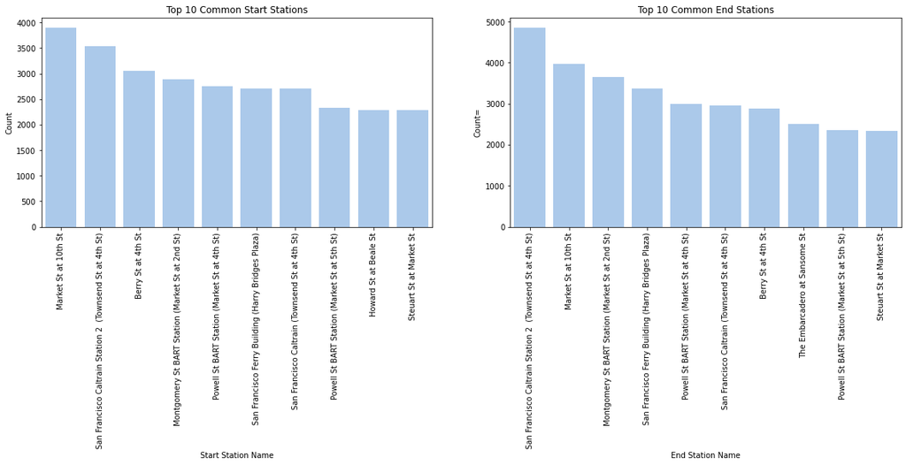

```python
plt.figure(figsize = [20, 5])
#Histogramme on the left about the name of the start location
create_plot(data=df, x='start_station_name', order=start_station_order, title='Top 10 Common Start Stations', xlabel='Start Station Name', ylabel='Count',isSubplot=True, sp1=1, sp2=2, sp3=1, withRotation=True)
#Histogramme on the right about the name of the end location
create_plot(data=df, x='end_station_name', order=end_station_order, title='Top 10 Common End Stations', xlabel='End Station Name', ylabel='Count=',isSubplot=True, sp1=1,sp2=2,sp3= 2, withRotation=True)
```

# Observation

For the start location, customers and/subscribers start mostly from the following location respectively: Market St at 10th St, San Fransisco Caltrain Station 2, and Berry St at 4th St.

For the end location, they stop mostly at the following respective locations: San Fransisco Caltrain Station 2, Market St at 10th St, and Montgomery St BART Station.

We can say the these are the most famous stations for bike rent. The choice of these stations can be dependent on many variables: preferences of the customers, famousness of these location compared to other ones, more targeted marketing and promotion acitivities are focused on these areas, or simply closeness to the customers.

To be able to answer these questions, it is required to have more data that is not present in this dataset.

# Most Used Bikes

#### Question: Are there specific most used bikes?

#### Visualization

```python
df.bike_id.nunique()
```

```
4618
```

There are 4618 bikes available in different stations. We will explore the most used bikes and understand whether there is a preference in bikes.

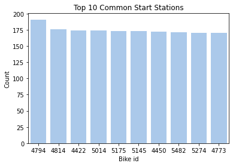

```python
type_order = df['bike_id'].value_counts().head(10).index
create_plot(x='bike_id', title='Top 10 Common Start Stations', data=df, order=type_order,isSubplot=False, xlabel='Bike id', ylabel='Count')
```

#### Observation

Based on this histogram, we can conclude that there was no major difference between the different bikes as the count is close. Therefore, we can say that customers/subscribers did not have any prefered bike over another.

### User Type: Customer vs Subscriber

#### Question: What are the proportions of customers and subscribers?

#### Visualization

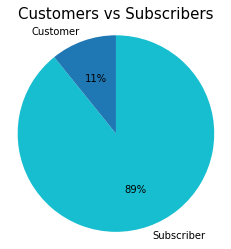

```python
base_color = ['tab:cyan', 'tab:blue']
sorted_type = df['user_type'].value_counts()
create_pie_plot(labels = sorted_type.index, title='Customers vs Subscribers', data=df, order=sorted_type,colors = base_color)
```

#### Observation

The pie chart illustrates that 89% of the members of GoBike are subscribers compared to only 11% of customers.

### Members of GoBike by Gender

#### Question: What is the distribution of gender among the members?

#### Visualization

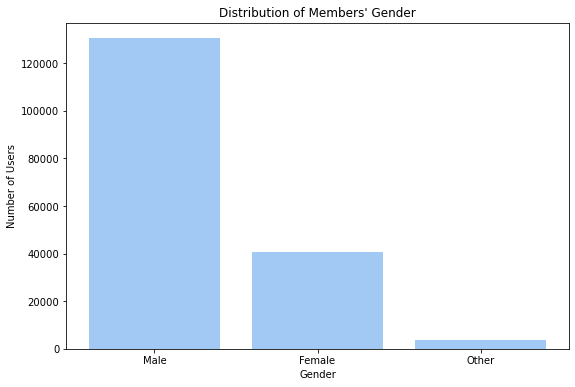

```python
plt.figure(figsize=[9,6])
create_bar_plot(x = df.member_gender.value_counts().keys(), height = df.member_gender.value_counts(), colors = color[0],xlabel='Gender',ylabel='Number of Users', title="Distribution of Members' Gender")
```

#### Observation

The bar plot shows that the mojority of members are males (more than 120000), less than a half are females, and a minority is identified as other.

#### Question: What are the proportion of each gender?

#### Visulization

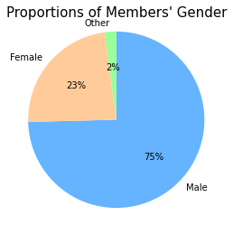

```python
base_color = ['#66b3ff','#ffcc99','#99ff99']
sorted_type = df['member_gender'].value_counts()
create_pie_plot(data=df, order=sorted_type, title = "Proportions of Members' Gender", labels = sorted_type.index, colors = base_color)
```

#### Observation:

The pie chart indicates that Males compose 75% of the members while females are 23% and other are only 2%.

### Members Birth Year

#### What is the distribution of members' ages?

#### Visualization

```python
df.member_birth_year.value_counts()
```

```
1988.0    10214
1993.0     9323
1989.0     8967
1990.0     8640
1991.0     8484
          ...
1928.0        1
1878.0        1
1930.0        1
1910.0        1
1927.0        1
Name: member_birth_year, Length: 75, dtype: int64
```

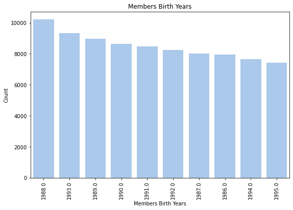

```python
type_order = df['member_birth_year'].value_counts().head(10).index
plt.figure(figsize=[20,6])
create_plot(data=df, x='member_birth_year', order=type_order, title='Members Birth Years', xlabel='Members Birth Years', ylabel='Count',isSubplot=True, sp1=1, sp2=2, sp3=1, withRotation=True)
```

#### Observation

This bar chart shows that the more than 10000 members are born in 1988, in other words, they have 34 years old.

For a better exploration of members age, we will calculate the ages first and display its distribution.

#### Members Age

```python
df['member_age'] = 2022-df['member_birth_year']
```

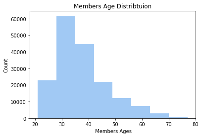

```python
bins = np.arange(0, df['member_age'].max()+7, 7)
plt.xlim(18, 80)
create_histogramme (data = df, x = 'member_age', bins = bins, color = color[0], title = 'Members Age Distribtuion', xlabel = ' Members Ages' , ylabel = 'Count')
```

#### Observation

The histogram shows a peak between 30 and 35 years old. And according to the previous chart, we can conclude that largest group of members are aged 34 years old. Therfore, we can state that the majority of the members use the bikes as a necessary transportation mean (work, for instance).

### Trip Durations in Seconds

#### Question: How long is a bike ride in seconds?

#### Visualization

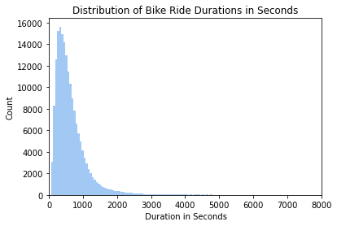

```python
bins = np.arange(0, df['duration_sec'].max()+100, 60)
plt.xlim(0,8000)
create_histogramme (data = df, x = 'duration_sec', bins = bins, color = color[0], title = 'Distribution of Bike Ride Durations in Seconds', xlabel = ' Duration in Seconds' , ylabel = 'Count')
```

### Trip Durations in Minutes

```python
df['duration_minute'] = df['duration_sec']/60
```

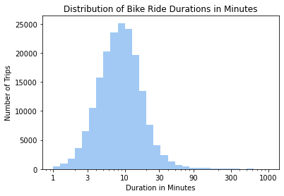

```python
bins = 10**np.arange(0 , 3 + 0.1 , 0.1)
xlabel =  [ 1 , 3, 10, 30, 90, 300, 1000]
labels = ['{}'.format(i) for i in xlabel]
plt.xscale('log');
plt.xticks(xlabel,labels);
create_histogramme (data = df, x = 'duration_minute', bins = bins, color = color[0], title = 'Distribution of Bike Ride Durations in Minutes', xlabel ='Duration in Minutes', ylabel = 'Number of Trips')
```

#### Observation

Based on the histogram of the Trip Duration in Minutes, we can state the following:

- Nearly 25000 bike rides lasted 10 minutes.
- The majority of bike trips last between 3 minutes and 30 minutes.
- Half of the bike trips last less than 10 minutes.

### Prefered Biking Month

```python
df['month'] = pd.DatetimeIndex(df['start_time']).month
df.month.value_counts()
```

```
2    183215
Name: month, dtype: int64
```

Our dataframe contains data only for 2nd month of the year that is February. For that, we can not work on month as a variable. Instead we will work on days of this months.

### Prefered Biking Day - Star Days

#### Question: What are the most common or prefered start days?

#### Visualization

```python
df['day'] = pd.DatetimeIndex(df['start_time']).day
df.day.value_counts()
```

```
28    9821
20    9651
21    9527
19    9453
7     9230
22    9193
6     9052
11    8664
5     8484
12    8466
27    7706
15    7288
25    7025
14    6598
8     6352
1     6129
18    5627
4     5491
23    5435
26    5378
24    4490
17    4223
16    3992
10    3950
2     3229
13    3200
3     2840
9     2721
Name: day, dtype: int64
```

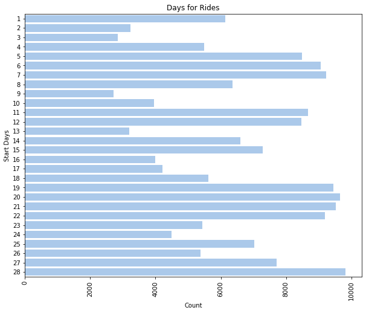

```python
plt.figure(figsize=(10 , 8))
create_plot(data = df , x= None, order = None, title = 'Days for Rides' , xlabel = 'Count', ylabel = 'Start Days', isSubplot = False, sp1=1, sp2=2, sp3=1, y='day', withRotation=True, plotType='countPlot', height=None)
```

#### Observation (1)

We will display the name of these days to get a better understanding of the characteristics of these days (workday vs weekend, for instance).

```python
#import datetime package to use to create a new dates columns
import datetime as dt
```

```python
stt_date = df.start_time.str.split(" ", n = 1, expand = True)
df['stt_date'] = stt_date[0]
days= ['Monday', 'Tuesday', 'Wednesday', 'Thursday', 'Friday', 'Saturday','Sunday']
day = []
for i in df.stt_date:
    day.append(days[dt.datetime.strptime(i, '%Y-%m-%d').weekday()])

df['stt_day'] = day
```

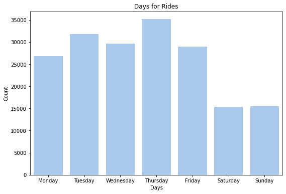

```python
order =  ['Monday', 'Tuesday', 'Wednesday', 'Thursday', 'Friday', 'Saturday', 'Sunday']
plt.figure(figsize=(9,6))
create_plot(data = df, x = 'stt_day', order = order, title = 'Days for Rides', xlabel = 'Days', ylabel = 'Count', isSubplot = False, sp1=1, sp2=2, sp3=1, y=None, withRotation=False, plotType='countPlot', height=None)
```

#### Observation (2)

This histogram shows that most members use the bikes on weekdays with two peaks on Tuesday and Thursday which is in accordance to the dates extracted from the previous bar chart.

### Prefered Biking Day - End Days

#### Question: What are the most common or prefered end days?

#### Visualization

In this section, we will replicate the same work done with the start das to check whether a bike ride can take more than one day.

```python
df['end_day'] = pd.DatetimeIndex(df['end_time']).day
df.end_day.value_counts()
```

```
28    9822
20    9648
21    9531
19    9454
7     9225
22    9182
6     9051
11    8662
5     8483
12    8474
27    7694
15    7292
25    7034
14    6586
8     6358
1     6130
18    5631
4     5487
23    5436
26    5377
24    4495
17    4225
16    3987
10    3943
2     3239
13    3206
3     2840
9     2723
Name: end_day, dtype: int64
```

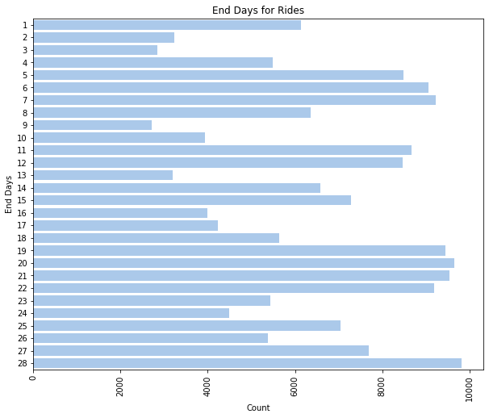

```python
plt.figure(figsize=(10 , 8))
create_plot(data = df , x= None, order = None, title = 'End Days for Rides' , xlabel = 'Count', ylabel = 'End Days', isSubplot = False, sp1=1, sp2=2, sp3=1, y='end_day', withRotation=True, plotType='countPlot', height=None)
```

#### Observation (1)

To further check whether bike rides starts and ends on the same dates, we will proceed with the analysis by presenting the names of the days.

```python
ed_date = df.end_time.str.split(" ", n = 1, expand = True)
df['ed_date'] = ed_date[0]
days= ['Monday', 'Tuesday', 'Wednesday', 'Thursday', 'Friday', 'Saturday','Sunday']
day = []
for i in df.ed_date:
    day.append(days[dt.datetime.strptime(i, '%Y-%m-%d').weekday()])

df['ed_day'] = day
```

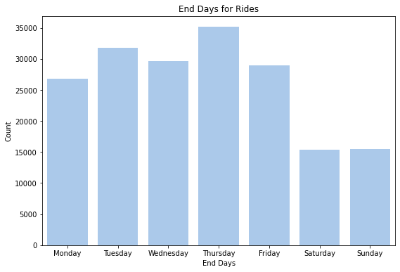

```python
order =  ['Monday', 'Tuesday', 'Wednesday', 'Thursday', 'Friday', 'Saturday', 'Sunday']
plt.figure(figsize=(9,6))
create_plot(data = df, x = 'ed_day', order = order, title = 'End Days for Rides', xlabel = 'End Days', ylabel = 'Count', isSubplot = False, sp1=1, sp2=2, sp3=1, y=None, withRotation=False, plotType='countPlot', height=None)
```

### Discuss the distribution(s) of your variable(s) of interest. Were there any unusual points? Did you need to perform any transformations?

> The duration in seconds was not clearly indicative to the trip duration, for that, it was crucial to transform the data from seconds to minutes to be intrepeted.

> The start and end stations were really numerous. No transformation has been made, but only the top 10 were considered for interpretation. Still, it was really valuable as information for this analysis because there was no difference to provide insightful conclusions.

> The dataframe has only one month, February, which did not allow the analysis of the rides distrubtion per month.

### Of the features you investigated, were there any unusual distributions? Did you perform any operations on the data to tidy, adjust, or change the form of the data? If so, why did you do this?

> The data was clear before starting the univariate exploration, for that, only the creation of new columns was required. The columns that wew generated are: Duration in minutes, day columns, day names column, age columns to help further investigation and interpretations.

## Bivariate Exploration

### Relationship Between Bike Ride Time and Days of the Week

#### Question: Can the ride duration be affected by the days of the week?

#### Visualization

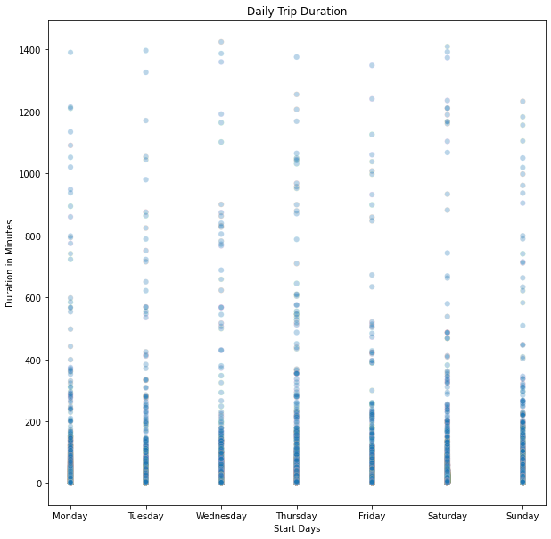

```python
plt.figure(figsize = [10,10])
sb.scatterplot(data = df, x = 'stt_day' , y = 'duration_minute', alpha = 0.3, edgecolor = color)
plt.title('Daily Trip Duration')
plt.xlabel('Start Days')
plt.ylabel('Duration in Minutes');
plt.show();
```

### Talk about some of the relationships you observed in this part of the investigation. How did the feature(s) of interest vary with other features in the dataset?

> The daily trip durations doesn't seem to have a high correlation with the day of the week.

> We can see a slight difference between the weekday and weekend where the weekend tend to have slightly longer trips.

### Did you observe any interesting relationships between the other features (not the main feature(s) of interest)?

> The relationship between trip duration and days of the week does not have a significant value, yet, it is interesting to understand that people use the bikes to necessary movement while on the weekends they can be used for leisure, therefore, more time.

## Multivariate Exploration

### Relationship Between User Type, Duration, and Days of the Week

#### Question: Does the user type affect the ride duration and days of the week?

#### Visualization

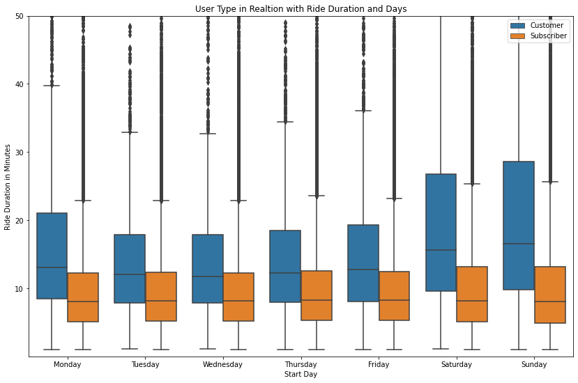

```python
plt.figure(figsize = [14,9])
sb.boxplot(data = df, x='stt_day', y='duration_minute', hue='user_type', order=["Monday", "Tuesday", "Wednesday", "Thursday", "Friday", "Saturday", "Sunday"] );
plt.ylim(0.01,50)
plt.xlabel('Start Day')
plt.ylabel('Ride Duration in Minutes')
plt.title('User Type in Realtion with Ride Duration and Days')
plt.legend(loc='upper right');
```

#### Observation

This boxplot shows that subscriber have a consistent usage in terms of days and duration of bikes in contrast with customers. Customers have longer durations during the weekends.

### Relationship Between Gender, Ride Duration, and Ride Days

#### Question: Can the gender affect the ride days and durations?

#### Visualization

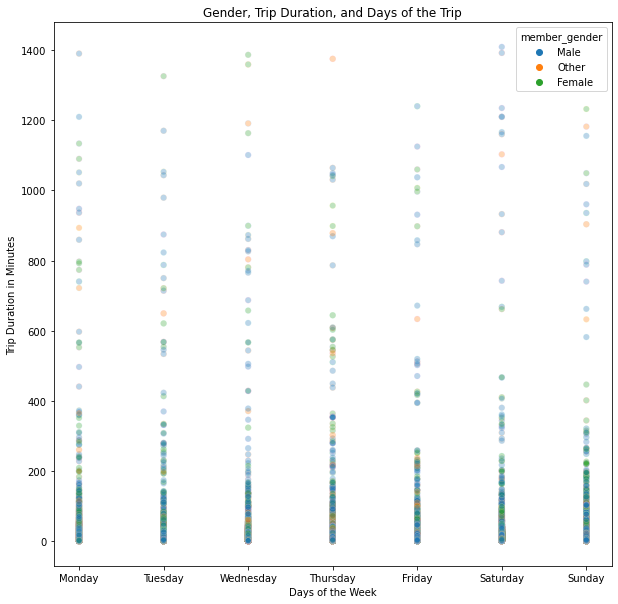

```python
plt.figure(figsize = [10,10])
sb.scatterplot(data = df, x = 'stt_day' , y = 'duration_minute', hue='member_gender', alpha = 0.3, edgecolor = color)
plt.title('Gender, Trip Duration, and Days of the Trip')
plt.xlabel('Days of the Week')
plt.ylabel('Trip Duration in Minutes');
```

### Relationship Between Gender, Age, and Ride Duration

#### Question: How can the ride duration be different in different age groups and gender?

#### Visulization

```python
# Create the age groups
df['age_groups'] = df['member_age'].apply(lambda x: '10 - 20' if 10<x<=20
                                                  else '20 - 30' if 20<x<=30
                                                  else '30 - 40' if 30<x<=40
                                                  else '40 - 50' if 40<x<=50
                                                  else '50 - 60' if 50<x<=60
                                                  else '60+' if x>60
                                                  else x);
df.age_groups.value_counts()
```

```
30 - 40    76788
20 - 30    48176
40 - 50    30207
50 - 60    14000
60+         5781
Name: age_groups, dtype: int64
```

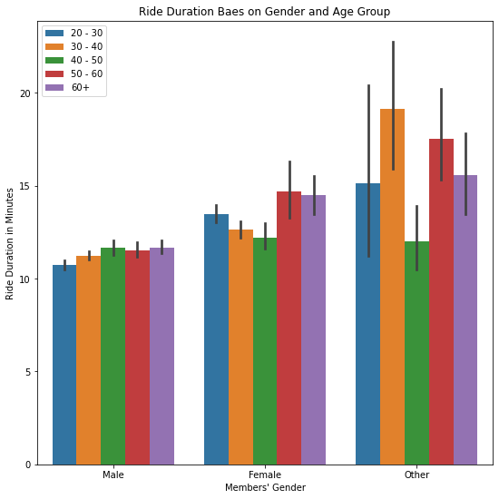

```python
plt.figure(figsize = [9, 9])

ax = sb.barplot(x='member_gender', y = 'duration_minute', hue='age_groups', data=df.sort_values(by= 'age_groups'))
plt.title('Ride Duration Baes on Gender and Age Group')
plt.xlabel("Members' Gender")
plt.ylabel('Ride Duration in Minutes')
leg = ax.legend()
```

### Talk about some of the relationships you observed in this part of the investigation. Were there features that strengthened each other in terms of looking at your feature(s) of interest?

> The relationships between features in the three visualizations strengthened each other and provided interesting interpretations.

> Female has longer rides than males.

### Were there any interesting or surprising interactions between features?

> Another interesting interpretation is that the females has the longest rides, in almost all age groups, than males.

## Conclusions

> People with most trip are aged between 30 and 35 years old, which can be explained by the fact that this age group is the most present in the dataframe.

> On average, most trips last 10 minutes and more than a half of trips are less than 30 minutes.

### Export the Clean Dataset

```python
# Code
df.to_csv('df_clean.csv', index=None)
df_check = pd.read_csv('df_clean.csv')

# Test
df_check
```

|  | duration_sec | start_time | end_time | start_station_id | start_station_name | end_station_id | end_station_name | bike_id | user_type | member_birth_year | ... | member_age | duration_minute | month | day | stt_date | stt_day | end_day | ed_date | ed_day | age_groups |
| --- | --- | --- | --- | --- | --- | --- | --- | --- | --- | --- | --- | --- | --- | --- | --- | --- | --- | --- | --- | --- | --- |
| 0 | 52185 | 2019-02-28 17:32:10.1450 | 2019-03-01 08:01:55.9750 | 21.0 | Montgomery St BART Station (Market St at 2nd St) | 13.0 | Commercial St at Montgomery St | 4902 | Customer | 1984.0 | ... | 38.0 | 869.750000 | 2 | 28 | 2019-02-28 | Thursday | 1 | 2019-03-01 | Friday | 30 - 40 |
| 1 | 42521 | 2019-02-28 18:53:21.7890 | 2019-03-01 06:42:03.0560 | 23.0 | The Embarcadero at Steuart St | 81.0 | Berry St at 4th St | 2535 | Customer | NaN | ... | NaN | 708.683333 | 2 | 28 | 2019-02-28 | Thursday | 1 | 2019-03-01 | Friday | NaN |
| 2 | 61854 | 2019-02-28 12:13:13.2180 | 2019-03-01 05:24:08.1460 | 86.0 | Market St at Dolores St | 3.0 | Powell St BART Station (Market St at 4th St) | 5905 | Customer | 1972.0 | ... | 50.0 | 1030.900000 | 2 | 28 | 2019-02-28 | Thursday | 1 | 2019-03-01 | Friday | 40 - 50 |
| 3 | 36490 | 2019-02-28 17:54:26.0100 | 2019-03-01 04:02:36.8420 | 375.0 | Grove St at Masonic Ave | 70.0 | Central Ave at Fell St | 6638 | Subscriber | 1989.0 | ... | 33.0 | 608.166667 | 2 | 28 | 2019-02-28 | Thursday | 1 | 2019-03-01 | Friday | 30 - 40 |
| 4 | 1585 | 2019-02-28 23:54:18.5490 | 2019-03-01 00:20:44.0740 | 7.0 | Frank H Ogawa Plaza | 222.0 | 10th Ave at E 15th St | 4898 | Subscriber | 1974.0 | ... | 48.0 | 26.416667 | 2 | 28 | 2019-02-28 | Thursday | 1 | 2019-03-01 | Friday | 40 - 50 |
| ... | ... | ... | ... | ... | ... | ... | ... | ... | ... | ... | ... | ... | ... | ... | ... | ... | ... | ... | ... | ... | ... |
| 183210 | 480 | 2019-02-01 00:04:49.7240 | 2019-02-01 00:12:50.0340 | 27.0 | Beale St at Harrison St | 324.0 | Union Square (Powell St at Post St) | 4832 | Subscriber | 1996.0 | ... | 26.0 | 8.000000 | 2 | 1 | 2019-02-01 | Friday | 1 | 2019-02-01 | Friday | 20 - 30 |
| 183211 | 313 | 2019-02-01 00:05:34.7440 | 2019-02-01 00:10:48.5020 | 21.0 | Montgomery St BART Station (Market St at 2nd St) | 66.0 | 3rd St at Townsend St | 4960 | Subscriber | 1984.0 | ... | 38.0 | 5.216667 | 2 | 1 | 2019-02-01 | Friday | 1 | 2019-02-01 | Friday | 30 - 40 |
| 183212 | 141 | 2019-02-01 00:06:05.5490 | 2019-02-01 00:08:27.2200 | 278.0 | The Alameda at Bush St | 277.0 | Morrison Ave at Julian St | 3824 | Subscriber | 1990.0 | ... | 32.0 | 2.350000 | 2 | 1 | 2019-02-01 | Friday | 1 | 2019-02-01 | Friday | 30 - 40 |
| 183213 | 139 | 2019-02-01 00:05:34.3600 | 2019-02-01 00:07:54.2870 | 220.0 | San Pablo Ave at MLK Jr Way | 216.0 | San Pablo Ave at 27th St | 5095 | Subscriber | 1988.0 | ... | 34.0 | 2.316667 | 2 | 1 | 2019-02-01 | Friday | 1 | 2019-02-01 | Friday | 30 - 40 |
| 183214 | 271 | 2019-02-01 00:00:20.6360 | 2019-02-01 00:04:52.0580 | 24.0 | Spear St at Folsom St | 37.0 | 2nd St at Folsom St | 1057 | Subscriber | 1989.0 | ... | 33.0 | 4.516667 | 2 | 1 | 2019-02-01 | Friday | 1 | 2019-02-01 | Friday | 30 - 40 |

183215 rows × 22 columns